## Assignment 7

#### Due Sunday, April 2, 11:59 PM CT

### Preliminaries

- Directories
  - COURSE/homework/
  - COURSE/homework/hw07/
  - COURSE/data/
  - COURSE/scripts/
- Files
  - COURSE/homework/hw07/hw07.Rmd
  - COURSE/scripts/viridis.R
  - COURSE/scripts/ggprob.R

### Aims

- Practice probability and the binomial distribution

### Problems

1. A discrete random variable $X$ has possible values 0, 1, 2, 3, 4, 5, 6, 7, 8 with the following partial probability distribution. The missing probabilities $\mathsf{P}(X=7)$ and $\mathsf{P}(X=8)$ are equal to each other.

| x | 0 | 1 | 2 | 3 | 4 | 5 | 6 | 7 | 8 |
| --- | --- | --- | --- | --- | --- | --- | --- | --- | --- |
| P(X=x) | 0.04 | 0.06 | 0.11 | 0.12 | 0.14 | 0.17 | 0.2 | NA | NA |

- Put the values `x = 0:8` and the tabled probabilities `p` into a data frame (use `tibble()`).

```r
dataframe = tibble(x = c(0:8),
                   p = c(0.04, 0.06, 0.11, 0.12, 0.14, 0.17, 0.2, NA, NA))
```

- Write code to calculate the missing values for $\mathsf{P}(X=7) = \mathsf{P}(X = 8)$ and replace the missing values with these calculated values into your data frame.

```r
prob7 = (1-sum(dataframe$p[0:7]))/2
prob8 = prob7
prob7
```

```
## [1] 0.08
```

```r
prob8
```

```
## [1] 0.08
```

```r
dataframe$p[which(is.na(dataframe$p))] <- prob7
dataframe
```

```
## # A tibble: 9 × 2
##       x      p
##   <int>  <dbl>
## 1     0 0.04
## 2     1 0.06
## 3     2 0.11
## 4     3 0.12
## 5     4 0.14
## 6     5 0.17
## 7     6 0.2
## 8     7 0.0800
## 9     8 0.0800
```

- Verify that the sum of all probabilities is 1.

```r
sum(dataframe$p)
```

```
## [1] 1
```

- Calculate the mean, variance, and standard deviation of this distribution.

```r
meandataframe = sum(dataframe$x)*sum(dataframe$p)
stddevdataframe = sqrt(meandataframe*(1-sum(dataframe$p)))
variancedataframe = stddevdataframe*stddevdataframe
meandataframe
```

```
## [1] 36
```

```r
stddevdataframe
```

```
## [1] 0
```

```r
variancedataframe
```

```
## [1] 0
```

2. Suppose you have a random variable $X \sim \text{Binomial}(120, 0.2)$.
- 2a. Calculate and report the mean and standard deviation of the distribution.

```r
mean = 120*.2
stddev = sqrt(mean*(1-.2))
mean
```

```
## [1] 24
```

```r
stddev
```

```
## [1] 4.38178
```

- 2b. Calculate and report the probability that the random variable is exactly equal to 20, $\mathsf{P}(X = 20)$.

```r
probability = dbinom(100*.2, 100, .2)
probability
```

```
## [1] 0.09930021
```

- 2c. Calculate and report the probability that $X$ equals 20 or more, $\mathsf{P}(X \ge 20)$.

```r
probability2 = dbinom(20, 120, 0.2)
probability2
```

```
## [1] 0.06293094
```

- 2d. Draw a graph of the binomial distribution with vertical lines at the mean (red and dashed), and 1, 2, and 3 standard deviations above and below the mean (red and dotted).

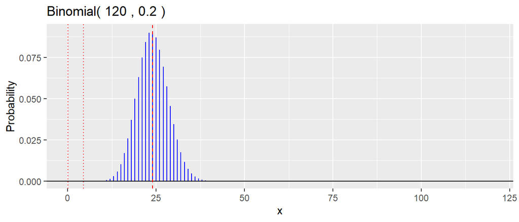

```r
gbinom(120, 0.2)+
  geom_vline(xintercept = mean, color = "red", linetype = "dashed")+
  geom_vline(xintercept = stddev, color = "red", linetype = "dotted")+
  geom_vline(xintercept = probability, color = "red", linetype = "dotted")+
  geom_vline(xintercept = probability2, color = "red", linetype = "dotted")
```

3. What is the probability that $X$ from Problem 2 is within one, two, and three standard deviations of the mean? Round each probability to four decimal places.

```r
stddev1mean=mean-stddev
stddev2mean=mean-probability
stddev3mean=mean-probability2
round(stddev1mean,digit = 4)
```

```
## [1] 19.6182
```

```r
round(stddev2mean,digit = 4)
```

```
## [1] 23.9007
```

```r
round(stddev3mean,digit = 4)
```

```
## [1] 23.9371
```

4. The following code makes a graph of the cumulative distribution function for the $\text{Binomial}(7, 0.3)$ distribution, that is $F(x) = \mathsf{P}(X \le x)$. This is the function which is calculated by the base R function `pbinom()`.
- Modify the code to add a horizontal red dotted line at 0.4.

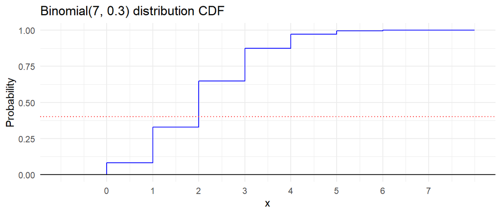

```r
prob4 = tibble(
  x = seq(-1,8,1),
  p = dbinom(x, 7, 0.3),
  cdf = pbinom(x, 7, 0.3))

ggplot(prob4, aes(x = x, y = cdf )) +
  geom_step(color = "blue") +
  geom_hline(yintercept = 0) +
  scale_x_continuous(breaks = 0:7) +
  geom_hline(slope = 0, yintercept = 0.4, color = "red", linetype = "dotted")+
  xlab("x") +
  ylab("Probability") +
  ggtitle("Binomial(7, 0.3) distribution CDF") +
  theme_minimal()
```

- Calculate the 0.4 quantile of the $\text{Binomial}(7, 0.3)$

```r
quantile0.4 = qbinom(0.4, 7, 0.3)
quantile0.4
```

```
## [1] 2
```

- Explain how the value of the quantile is related to the red dotted line which you added to the plot.

> the quantile of 0.4 equal to 2, and 2 is the line where it intersects with the red dotted line
- Use the graph to determine the 0.75 quantile of this distribution. Then verify your observation with a calculation.

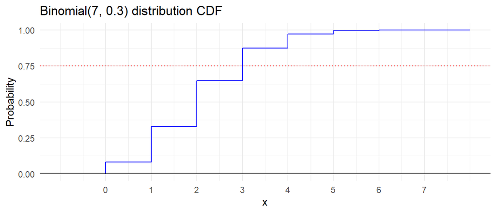

```r
ggplot(prob4, aes(x = x, y = cdf )) +
  geom_step(color = "blue") +
  geom_hline(yintercept = 0) +
  scale_x_continuous(breaks = 0:7) +
  geom_hline(slope = 0, yintercept = 0.75, color = "red", linetype = "dotted")+
  xlab("x") +
  ylab("Probability") +
  ggtitle("Binomial(7, 0.3) distribution CDF") +
  theme_minimal()
```

```r
qunatile0.75 = qbinom(0.75, 7, 0.3)
qunatile0.75
```

```
## [1] 3
```

5. In a large population of likely voters, the proportion of voters who plan to vote for candidate A is $p = 0.52$. In a random sample of 600 likely voters, what is the probability that the proportion of voters who plan to vote for candidate A is less than 50% (the number of such voters is less than 300)?

```r
nvote = 600
pvote = 0.52
votesample = rbinom(nvote, nvote, pvote )

total = sum(votesample < 300)

voterprob = total/nvote
voterprob
```

```
## [1] 0.1233333
```

6. Basketball player 1 makes 80% of their free throws and basketball players 2 makes 70% of their free throws. Assume all of their free throws attempts are independent. If each player takes ten free throws and $X$ is the total number of free throws they make, does $X$ have a binomial distribution? If yes, specify the parameters $n$ and $p$. If not, explain why not.

> For BP1 and BP2, “n” is the same for both of them. For BP1, p is 0.8, and mu is 8. For BP2, p is 0.7 and mu is 7.
7. What is the smallest number of coin tosses $n$ of a fair coin so that the chance of getting 50 or more heads exceeds 90%? (You may need to do some trial and error. Alternatively, think of creating a data frame with a column `n` and a column for the probability and using this to find the answer.)

```r
cointoss = 1-pbinom(49, 113, 0.5)
cointoss
```

```
## [1] 0.9062006
```

8. The random variable $X$ has the $\text{Binomial}(100, 0.2)$ distribution.
- Find an integer $a$ so that $P(X \le a) \ge 0.5$ and $P(X \ge a) \ge 0.5$.
- Show the values of $a$, $P(X \le a)$, and $P(X \ge a)$.

```r
# binomial(n=100, p = 0.2) and where it is <0.5 and >0.5
# a=0.5
# n10 = 100
# p10 = 0.2
# a_val1 = function(a){
#   b = qnorm(a, n10, p10)
#   c = pnorm(b, n10, p10)
#   return(c)
# }
# a_val2 = function(a){
#   b = qnorm(a, n10, p10)
#   c = pnorm(b, n10, p10)
#   return(c)
# }
#
# a_val1(a)
# a_val2(a)
a=0.5
n10 = 100*.2
p10 = sqrt(100*.2*(1-.2))
a_val1 = function(a){
  b = qnorm(a, n10, p10)
  c = pnorm(b, n10, p10)
  return(c)
}
a_val2 = function(a){
  b = qnorm(a, n10, p10)
  c = pnorm(b, n10, p10)
  return(c)
}

a_val1(a)
```

```
## [1] 0.5
```

```r
a_val2(a)
```

```
## [1] 0.5
```